# ACP con imputación multivariada - Exoplanetas NASA

Daniel Alvarado - 145310

2026-10-18

# Introducción y objetivos

Este documento extiende el EDA inicial (`EDA_Exoplanets.Rmd`) con un **Análisis de Componentes Principales (ACP)** sobre **las 16 variables numéricas físicas** del dataset, no solo las 6 de la primera caracterización.

El reto central es el nulo de la **masa planetaria** (`pl_bmasse`): 83% de los 36.418 registros. Se evalúa primero la viabilidad del análisis de casos completos y, al no serlo, se aplica **imputación multivariada** con `missMDA::imputePCA()`, **sin imputar nunca la masa**.

**Stack:** `FactoMineR` + `missMDA`, sobre el proyecto `renv` existente.

> El plan completo de este análisis, con su justificación fase por fase, está en `PLAN_acp.md`.

```r
raw_data <- read.csv("data_descriptiva_multi/NASA_Exoplanet_Archive_Data.csv",
                     stringsAsFactors = FALSE)
cat("Registros originales:", nrow(raw_data), "\n")
```

```
## Registros originales: 36418
```

```r
cat("Columnas originales :", ncol(raw_data), "\n")
```

```
## Columnas originales : 91
```

# Fase 1 — Selección de variables

## Las 16 variables incluidas

Se analizaron **21 columnas numéricas de contenido**, descartando las de metadatos de precisión (`*err1`, `*err2`, `*lim`). De ellas, **16 entran al ACP**:

```r
tibble(variable = VARS_ACP) %>%
  kable(caption = "Variables numéricas incluidas en el ACP") %>%
  kable_styling(bootstrap_options = c("striped", "hover", "condensed"))
```

Variables numéricas incluidas en el ACP

| variable |
| --- |
| pl_orbper |
| pl_orbsmax |
| pl_rade |
| pl_bmasse |
| pl_orbeccen |
| pl_insol |
| pl_eqt |
| st_teff |
| st_rad |
| st_mass |
| st_met |
| st_logg |
| sy_dist |
| sy_vmag |
| sy_kmag |
| sy_gaiamag |

## Las 5 variables excluidas y su justificación

Documentado explícitamente por requerimiento del análisis:

```r
tibble(
  variable = names(EXCLUIDAS_ACP),
  motivo   = unname(EXCLUIDAS_ACP)
) %>%
  kable(caption = "Variables numéricas EXCLUIDAS del ACP y por qué") %>%
  kable_styling(bootstrap_options = c("striped", "hover", "condensed")) %>%
  column_spec(2, width = "60em")
```

Variables numéricas EXCLUIDAS del ACP y por qué

| variable | motivo |
| --- | --- |
| pl_radj | duplicado exacto de pl_rade en radios de Jupiter (colinealidad perfecta) |
| pl_bmassj | duplicado exacto de pl_bmasse en masas de Jupiter (colinealidad perfecta) |
| disc_year | metadato temporal, no propiedad fisica del planeta |
| sy_snum | conteo discreto con cardinalidad minima; mejor como suplementaria/ACM |
| sy_pnum | conteo discreto con poca cardinalidad; mejor como suplementaria/ACM |

**Resumen del motivo:**

- `pl_radj` y `pl_bmassj` son **duplicados exactos** de `pl_rade` y `pl_bmasse` en unidades de Júpiter → colinealidad perfecta, producirían eigenvalores 0.
- `disc_year` es un **metadato temporal**, no una propiedad física del planeta.
- `sy_snum` y `sy_pnum` son **conteos discretos** con cardinalidad baja; su lugar es como variables suplementarias o en el ACM (Fase 5).

## Transformación (decidida con datos)

La decisión `log10` no se tomó a priori sino midiendo la **asimetría** antes y después, dentro del subconjunto con masa:

```r
tibble(
  variable = VARS_ACP,
  log10    = ifelse(variable %in% VARS_LOG10, "Sí", "No")
) %>%
  kable(caption = "Transformación log10 aplicada por variable") %>%
  kable_styling(bootstrap_options = c("striped", "hover"))
```

Transformación log10 aplicada por variable

| variable | log10 |
| --- | --- |
| pl_orbper | Sí |
| pl_orbsmax | Sí |
| pl_rade | No |
| pl_bmasse | Sí |
| pl_orbeccen | No |
| pl_insol | Sí |
| pl_eqt | No |
| st_teff | Sí |
| st_rad | Sí |
| st_mass | Sí |
| st_met | No |
| st_logg | No |
| sy_dist | Sí |
| sy_vmag | No |
| sy_kmag | No |
| sy_gaiamag | No |

**Corrección importante:** a diferencia de una primera aproximación, **no** se aplicó log10 a las magnitudes (`sy_vmag`, `sy_kmag`, `sy_gaiamag`). Ya son logarítmicas por definición ($mag = -2.5\ \log_{10}(flux)$); transformarlas de nuevo **empeora** la asimetría y `sy_kmag` además tiene valores negativos (mín −3,04), incompatible con el logaritmo. Tampoco se transformó `pl_rade`, que dentro de este subconjunto ya es casi simétrica (asimetría 0,35).

# Fase 2 — Diagnóstico de nulos y viabilidad

## Restricción por masa

```r
sel <- seleccionar_variables_acp(raw_data, restringir_por_masa = TRUE)

# Cualitativas SUPLEMENTARIAS alineadas al mismo subset (mismo filtro de masa).
# Se usan solo para colorear/interpretar; no influyen en los ejes.
sup_cuali <- raw_data %>%
  filter(!is.na(pl_bmasse), pl_bmasse != "") %>%
  transmute(
    discoverymethod = factor(discoverymethod),
    soltype         = factor(soltype)
  )
stopifnot(nrow(sup_cuali) == nrow(sel$matriz))

tibble(
  concepto = c("Registros totales", "Con masa observada", "% masa observada",
               "Variables del ACP"),
  valor = c(sel$n_origen, sel$n_subset,
            sprintf("%.1f%%", sel$n_subset / sel$n_origen * 100),
            ncol(sel$matriz))
) %>%
  kable(caption = "Tamaño del subconjunto con masa planetaria observada") %>%
  kable_styling(bootstrap_options = c("striped", "hover"))
```

Tamaño del subconjunto con masa planetaria observada

| concepto | valor |
| --- | --- |
| Registros totales | 36418 |
| Con masa observada | 6207 |
| % masa observada | 17.0% |
| Variables del ACP | 16 |

> La masa se observa en el **17,0%** de los registros (6.207 de 36.418).

## Completitud y asimetría dentro del subconjunto

```r
diag <- diagnostico_nulos(sel$matriz)

diag$por_variable %>%
  arrange(desc(pct_nulos)) %>%
  mutate(pct_nulos = paste0(pct_nulos, "%")) %>%
  kable(caption = "Completitud por variable (subconjunto con masa, n = 6.207)") %>%
  kable_styling(bootstrap_options = c("striped", "hover", "condensed"))
```

Completitud por variable (subconjunto con masa, n = 6.207)

| variable | n_observados | n_nulos | pct_nulos | asimetria |
| --- | --- | --- | --- | --- |
| pl_insol | 652 | 5555 | 89.5% | -0.40 |
| pl_eqt | 1729 | 4478 | 72.1% | 0.47 |
| pl_rade | 2882 | 3325 | 53.6% | 0.35 |
| st_logg | 3651 | 2556 | 41.2% | -2.22 |
| st_met | 4080 | 2127 | 34.3% | 7.31 |
| st_rad | 4241 | 1966 | 31.7% | 1.24 |
| st_teff | 4426 | 1781 | 28.7% | 0.24 |
| pl_orbeccen | 4566 | 1641 | 26.4% | 1.63 |
| pl_orbsmax | 5231 | 976 | 15.7% | 0.67 |
| pl_orbper | 5359 | 848 | 13.7% | 0.70 |
| sy_gaiamag | 5488 | 719 | 11.6% | 0.08 |
| sy_kmag | 5518 | 689 | 11.1% | 0.61 |
| sy_vmag | 5525 | 682 | 11% | 1.11 |
| st_mass | 6022 | 185 | 3% | -2.07 |
| sy_dist | 6124 | 83 | 1.3% | 0.38 |
| pl_bmasse | 6207 | 0 | 0% | -0.34 |

## Resultado: el caso-completo NO es viable

```r
tibble(
  criterio = c("Casos completos encontrados",
               "Mínimo recomendado (5 obs/variable × 16 vars)",
               "Veredicto"),
  valor = c(diag$casos_completos,
            diag$min_recomendado,
            ifelse(diag$viabilidad, "VIABLE", "NO VIABLE → imputación obligatoria"))
) %>%
  kable(caption = "Evaluación de viabilidad del análisis de casos completos") %>%
  kable_styling(bootstrap_options = c("striped", "hover"))
```

Evaluación de viabilidad del análisis de casos completos

| criterio | valor |
| --- | --- |
| Casos completos encontrados | 349 |
| Mínimo recomendado (5 obs/variable × 16 vars) | 1000 |
| Veredicto | NO VIABLE → imputación obligatoria |

**Conclusión: se procede a imputación multivariada de las 15 variables no-masa.**

## Sesgo de selección (limitación a declarar)

El subconjunto con masa **no es representativo** del catálogo completo:

[figure not shown]

Distribución del método de descubrimiento: completo vs con masa

```r
metodos <- c("Transit", "Radial Velocity", "Microlensing", "Imaging")

comparacion <- bind_rows(
  raw_data %>%
    filter(discoverymethod %in% metodos) %>%
    count(origen = "Completo", discoverymethod),
  raw_data %>%
    filter(!is.na(pl_bmasse), pl_bmasse != "", discoverymethod %in% metodos) %>%
    count(origen = "Con masa", discoverymethod)
) %>%
  group_by(origen) %>%
  mutate(pct = n / sum(n) * 100) %>%
  ungroup()

ggplot(comparacion, aes(x = reorder(discoverymethod, pct), y = pct,
                        fill = origen)) +
  geom_col(position = "dodge", width = 0.75) +
  geom_text(aes(label = sprintf("%.1f%%", pct)),
            position = position_dodge(width = 0.75), vjust = -0.4, size = 3) +
  scale_fill_nasa(niveles = c("Completo", "Con masa")) +
  scale_y_continuous(expand = expansion(mult = c(0, 0.15))) +
  labs(title = "Sesgo de selección: método de descubrimiento",
       subtitle = "Los planetas con masa son mayoritariamente de Velocidad Radial, no de Tránsito",
       x = "Método de descubrimiento", y = "% de registros",
       fill = "Subconjunto", caption = "Fuente: NASA Exoplanet Archive") +
  theme_nasa() +
  theme(axis.text.x = element_text(angle = 20, hjust = 1))
```

```r
rm(comparacion)
```

```r
mediana <- function(df, v) median(as.numeric(df[[v]]), na.rm = TRUE)

tibble(
  variable = c("Radio planetario (R⊕)", "Período orbital (días)", "Distancia (pc)"),
  completo = c(mediana(raw_data, "pl_rade"),
               mediana(raw_data, "pl_orbper"),
               mediana(raw_data, "sy_dist")),
  con_masa = c(mediana(raw_data %>% filter(!is.na(pl_bmasse), pl_bmasse != ""), "pl_rade"),
               mediana(raw_data %>% filter(!is.na(pl_bmasse), pl_bmasse != ""), "pl_orbper"),
               mediana(raw_data %>% filter(!is.na(pl_bmasse), pl_bmasse != ""), "sy_dist"))
) %>%
  mutate(across(c(completo, con_masa), ~ round(.x, 2))) %>%
  kable(caption = "Medianas: catálogo completo vs subconjunto con masa") %>%
  kable_styling(bootstrap_options = c("striped", "hover"))
```

Medianas: catálogo completo vs subconjunto con masa

| variable | completo | con_masa |
| --- | --- | --- |
| Radio planetario (R⊕) | 2.29 | 9.89 |
| Período orbital (días) | 10.33 | 13.73 |
| Distancia (pc) | 594.46 | 136.76 |

> **Limitación del análisis:** el ACP describe la estructura de variación de los *exoplanetas con masa conocida*. No se generaliza a los ~30.000 planetas detectados solo por tránsito. Esto no es corregible con imputación; se declara como limitación metodológica.

# Fase 3 — Imputación multivariada

Se imputan las **15 variables no-masa** sobre los 6.207 registros. La masa **nunca** se imputa.

```r
imp <- imputar_acp(sel$matriz)

tibble(
  concepto = c("Método", "Componentes usados (ncp, por validación cruzada)",
               "Total de celdas imputadas", "Celdas imputadas en pl_bmasse"),
  valor = c("missMDA::imputePCA (imputación en espacio de componentes)",
            imp$ncp, paste0(imp$pct_imputado, "%"), "0,0% (restringida, no se imputa)")
) %>%
  kable(caption = "Parámetros de la imputación") %>%
  kable_styling(bootstrap_options = c("striped", "hover"))
```

Parámetros de la imputación

| concepto | valor |
| --- | --- |
| Método | missMDA::imputePCA (imputación en espacio de componentes) |
| Componentes usados (ncp, por validación cruzada) | 2 |
| Total de celdas imputadas | 27.8% |
| Celdas imputadas en pl_bmasse | 0,0% (restringida, no se imputa) |

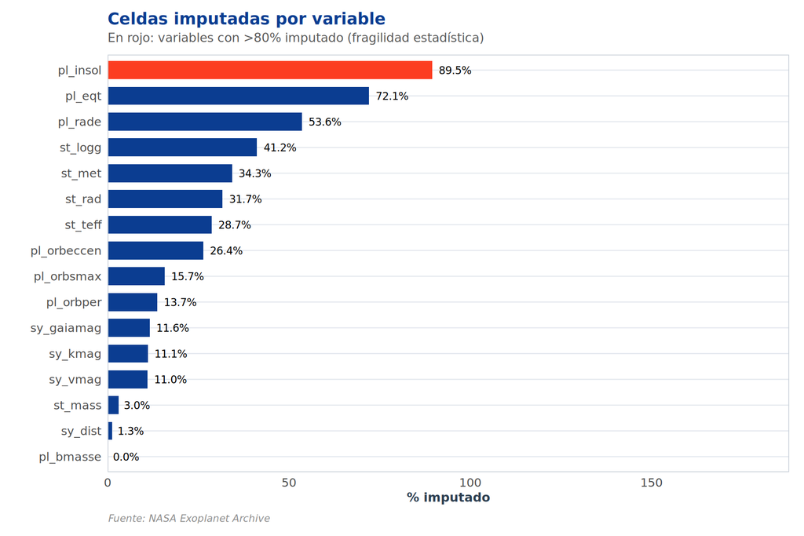

Porcentaje de celdas imputadas por variable

```r
tibble(variable = names(imp$celdas_por_var), pct = as.numeric(imp$celdas_por_var)) %>%
  arrange(desc(pct)) %>%
  mutate(variable = factor(variable, levels = rev(variable))) %>%
  ggplot(aes(x = variable, y = pct, fill = pct > 80)) +
  geom_col(width = 0.7) +
  geom_text(aes(label = sprintf("%.1f%%", pct)), hjust = -0.2, size = 3) +
  scale_fill_nasa(niveles = c(FALSE, TRUE), guide = "none") +
  coord_flip() +
  scale_y_continuous(expand = expansion(mult = c(0, 1.1))) +
  labs(title = "Celdas imputadas por variable",
       subtitle = "En rojo: variables con >80% imputado (fragilidad estadística)",
       x = "", y = "% imputado", caption = "Fuente: NASA Exoplanet Archive") +
  theme_nasa()
```

**Advertencia de fragilidad:** `pl_insol` tiene **89,5%** de sus celdas imputadas y `pl_eqt` 72,1%. Una variable mayoritariamente reconstruida aporta más ruido que señal. Por eso, junto al ACP completo se reporta un **análisis de sensibilidad** (Fase 4.5) sin `pl_insol`.

## Validación de la imputación

```r
validacion <- tibble(
  variable = VARS_ACP,
  corr_orig_imp = map_dbl(VARS_ACP, function(v) {
    orig <- sel$matriz[[v]]
    impv <- imp$X[, v]
    ok <- !is.na(orig)
    if (sum(ok) > 10) suppressWarnings(cor(orig[ok], impv[ok])) else NA_real_
  })
)

validacion %>%
  mutate(corr_orig_imp = round(corr_orig_imp, 3)) %>%
  arrange(desc(corr_orig_imp)) %>%
  kable(caption = "Correlación original vs imputado por variable (conserva la señal si se mantiene alta)") %>%
  kable_styling(bootstrap_options = c("striped", "hover"))
```

Correlación original vs imputado por variable (conserva la señal si se mantiene alta)

| variable | corr_orig_imp |
| --- | --- |
| pl_orbper | 1 |
| pl_orbsmax | 1 |
| pl_rade | 1 |
| pl_bmasse | 1 |
| pl_orbeccen | 1 |
| pl_insol | 1 |
| pl_eqt | 1 |
| st_teff | 1 |
| st_rad | 1 |
| st_mass | 1 |
| st_met | 1 |
| st_logg | 1 |
| sy_dist | 1 |
| sy_vmag | 1 |
| sy_kmag | 1 |
| sy_gaiamag | 1 |

```r
rm(validacion)
```

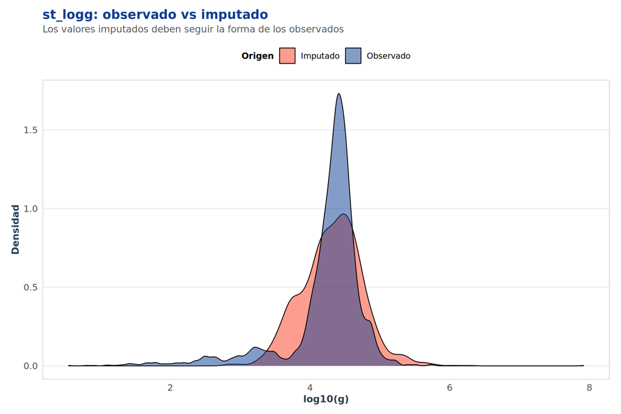

Comparación de densidad: observado vs imputado (st_logg)

```r
idx_var <- "st_logg"
orig_vals <- sel$matriz[[idx_var]]
ok <- !is.na(orig_vals)

tibble(
  valor = c(orig_vals[ok], imp$X[ok == FALSE, idx_var]),
  tipo  = rep(c("Observado", "Imputado"), c(sum(ok), sum(!ok)))
) %>%
  ggplot(aes(x = valor, fill = tipo)) +
  geom_density(alpha = 0.5, linewidth = 0.4) +
  scale_fill_nasa(niveles = c("Observado", "Imputado")) +
  labs(title = paste("st_logg: observado vs imputado"),
       subtitle = "Los valores imputados deben seguir la forma de los observados",
       x = "log10(g)", y = "Densidad", fill = "Origen") +
  theme_nasa()
```

# Fase 4 — ACP

## 4.1 Ejecución

```r
res <- correr_acp(imp$X, ncp = 5, quali_sup = sup_cuali)
```

Se usa `scale.unit = TRUE`, es decir se trabaja sobre la **matriz de correlación**, necesario por las unidades heterogéneas (días, Kelvin, R⊕, pc).

## 4.2 Eigenvalores y varianza explicada

```r
resumen_ejes(res, 5) %>%
  kable(caption = "Eigenvalores y varianza explicada por componente",
        digits = c(0, 3, 2, 2)) %>%
  kable_styling(bootstrap_options = c("striped", "hover", "condensed"))
```

Eigenvalores y varianza explicada por componente

| eje | eigenvalor | pct_var | pct_acum |
| --- | --- | --- | --- |
| 1 | 5.849 | 36.56 | 36.56 |
| 2 | 4.633 | 28.96 | 65.51 |
| 3 | 1.331 | 8.32 | 73.83 |
| 4 | 1.047 | 6.54 | 80.38 |
| 5 | 0.716 | 4.48 | 84.85 |

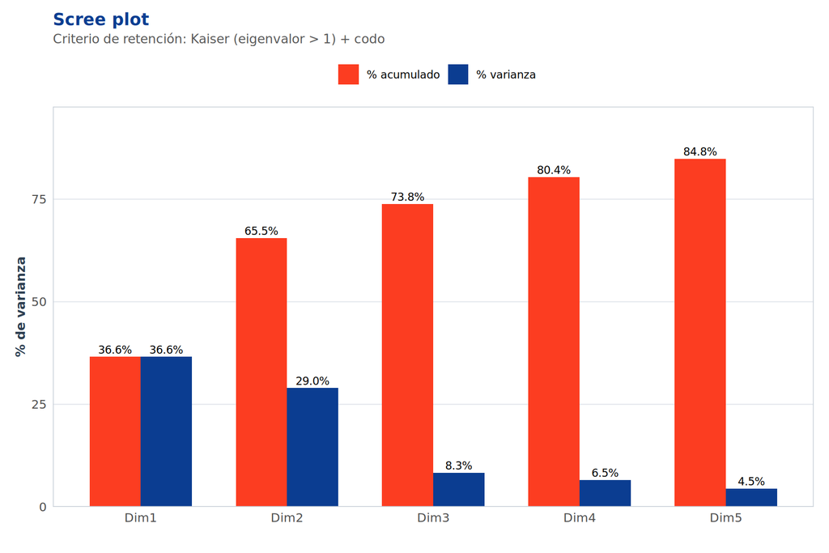

Scree plot: varianza explicada por componente

```r
tibble(
  eje = paste0("Dim", 1:5),
  pct = resumen_ejes(res, 5)$pct_var,
  acum = resumen_ejes(res, 5)$pct_acum
) %>%
  pivot_longer(-eje, names_to = "tipo", values_to = "valor") %>%
  mutate(tipo = recode(tipo, pct = "% varianza", acum = "% acumulado")) %>%
  ggplot(aes(x = eje, y = valor, fill = tipo)) +
  geom_col(position = "dodge", width = 0.7) +
  geom_text(aes(label = sprintf("%.1f%%", valor)),
            position = position_dodge(width = 0.7), vjust = -0.4, size = 3) +
  scale_fill_nasa(niveles = c("% varianza", "% acumulado")) +
  scale_y_continuous(expand = expansion(mult = c(0, 0.15))) +
  labs(title = "Scree plot", subtitle = "Criterio de retención: Kaiser (eigenvalor > 1) + codo",
       x = "", y = "% de varianza", fill = "") +
  theme_nasa()
```

**Retención:** los eigenvalores > 1 corresponden a los **primeros 4 componentes** (5.85, 4.63, 1.33, 1.05), que acumulan el **80,4%** de la varianza. El quinto cae a 0,72 (por debajo de Kaiser) y su aporte es marginal.

## 4.3 Interpretación de ejes

```r
aportes_variables(res, 4) %>%
  mutate(contribucion = round(contribucion, 2)) %>%
  pivot_wider(names_from = eje, values_from = contribucion) %>%
  mutate(across(starts_with("Dim"), ~ sprintf("%.2f", .x))) %>%
  kable(caption = "Aportes de cada variable a los 4 primeros ejes (%). Punto de referencia = 100/16 = 6.25",
        digits = 2) %>%
  kable_styling(bootstrap_options = c("striped", "hover", "condensed"))
```

Aportes de cada variable a los 4 primeros ejes (%). Punto de referencia = 100/16 = 6.25

| variable | Dim1 | Dim2 | Dim3 | Dim4 |
| --- | --- | --- | --- | --- |
| pl_orbper | 8.97 | 2.09 | 14.64 | 0.09 |
| pl_orbsmax | 4.47 | 0.24 | 39.44 | 2.56 |
| pl_rade | 6.96 | 8.16 | 0.00 | 0.00 |
| pl_bmasse | 8.17 | 2.99 | 4.63 | 0.29 |
| pl_orbeccen | 4.66 | 1.19 | 9.95 | 4.24 |
| pl_insol | 1.36 | 16.86 | 0.90 | 0.01 |
| pl_eqt | 1.78 | 15.39 | 1.03 | 0.02 |
| st_teff | 1.67 | 8.73 | 0.64 | 6.08 |
| st_rad | 12.69 | 1.64 | 1.18 | 4.80 |
| st_mass | 8.17 | 0.39 | 17.18 | 1.77 |
| st_met | 0.02 | 1.73 | 1.42 | 67.12 |
| st_logg | 11.88 | 0.71 | 1.24 | 9.05 |
| sy_dist | 1.49 | 16.34 | 0.59 | 2.28 |
| sy_vmag | 10.15 | 6.14 | 3.25 | 0.91 |
| sy_kmag | 7.85 | 10.13 | 1.53 | 0.09 |
| sy_gaiamag | 9.71 | 7.27 | 2.37 | 0.68 |

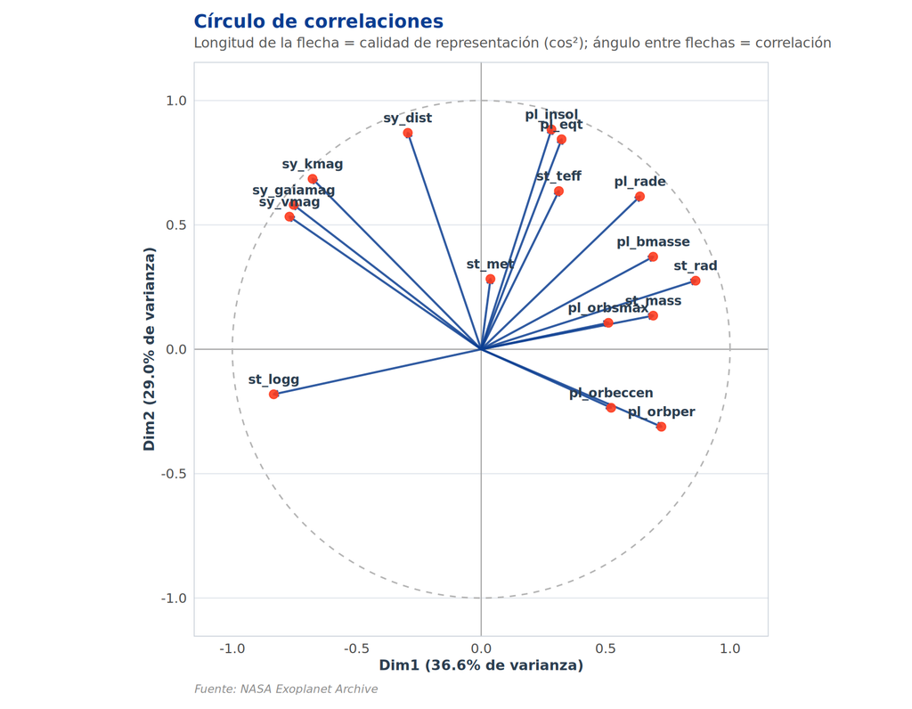

Círculo de correlaciones (Dim1 vs Dim2)

```r
plot_circulo_correlaciones(res, ejes = c(1, 2))
```

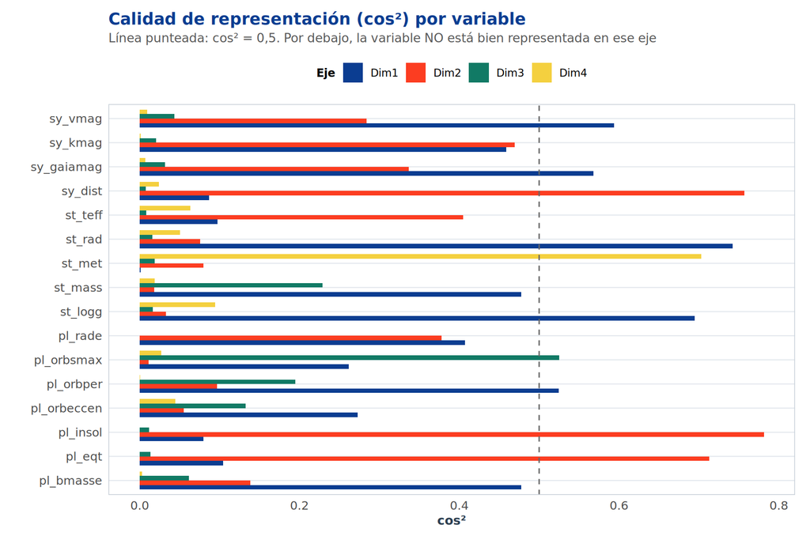

Calidad de representación (cos²) de las variables en los 4 primeros ejes

```r
cos2_variables(res, ncp = 4) %>%
  ggplot(aes(x = variable, y = cos2, fill = eje)) +
  geom_col(position = "dodge", width = 0.75) +
  geom_hline(yintercept = 0.5, linetype = "dashed", color = "gray40") +
  scale_fill_nasa(niveles = paste0("Dim", 1:4)) +
  coord_flip() +
  labs(title = "Calidad de representación (cos²) por variable",
       subtitle = "Línea punteada: cos² = 0,5. Por debajo, la variable NO está bien representada en ese eje",
       x = "", y = "cos²", fill = "Eje") +
  theme_nasa()
```

### Lectura de los ejes

**Dim2 (29,0% de varianza) — “Entorno térmico y distancia”** Dominada por `pl_insol` (16,86), `sy_dist` (16,34), `pl_eqt` (15,39), `sy_kmag` (10,13). Describe cuánta radiación recibe el planeta y qué tan lejos está: es el eje del **entorno de irradiación**.

```r
cat("Variables con mayor aporte a Dim1 (>= 6.25):\n")
```

```
## Variables con mayor aporte a Dim1 (>= 6.25):
```

```r
d1 <- res$var$contrib[, 1]
print(round(sort(d1[d1 >= 6.25], decreasing = TRUE), 2))
```

```
##     st_rad    st_logg    sy_vmag sy_gaiamag  pl_orbper    st_mass  pl_bmasse
##      12.69      11.88      10.15       9.71       8.97       8.17       8.17
##    sy_kmag    pl_rade
##       7.85       6.96
```

```r
cat("\nVariables con mayor aporte a Dim2 (>= 6.25):\n")
```

```
##
## Variables con mayor aporte a Dim2 (>= 6.25):
```

```r
d2 <- res$var$contrib[, 2]
print(round(sort(d2[d2 >= 6.25], decreasing = TRUE), 2))
```

```
##   pl_insol    sy_dist     pl_eqt    sy_kmag    st_teff    pl_rade sy_gaiamag
##      16.86      16.34      15.39      10.13       8.73       8.16       7.27
```

**Nota sobre `st_met`:** su cos² en Dim1 es prácticamente 0,001. La metalicidad estelar queda **casi sin representar** en los dos primeros ejes. Se recomienda tratarla como variable suplementaria en lugar de activa, o transformarla previamente (asimetría 7,31, con valores atípicos altos).

## 4.4 Mapa de individuos

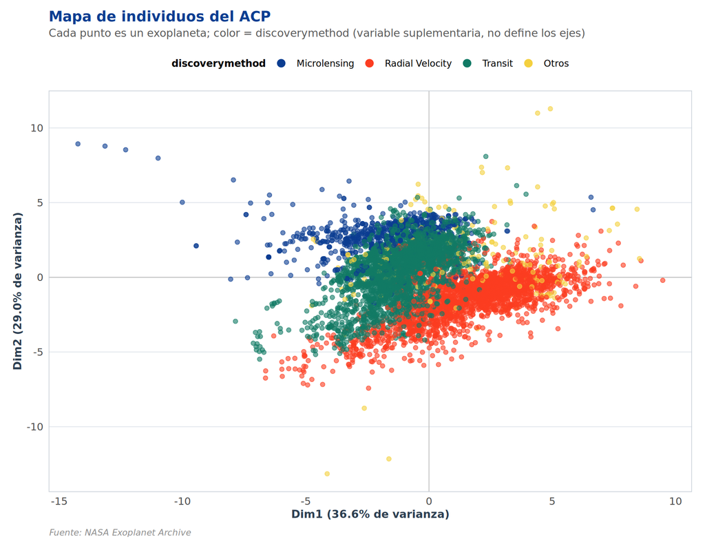

Mapa de individuos coloreado por método de descubrimiento

```r
# discoverymethod entra como variable SUPLEMENTARIA (no influye en los ejes)
plot_individuos_acp(res, grupo = "discoverymethod")
```

> Para colorear por `discoverymethod` sin que influya en los ejes, la variable se pasó como **suplementaria cualitativa** (`quali.sup`) en el ACP.

### Hallazgo: los métodos de descubrimiento se separan en el espacio del ACP

El mapa muestra una estructura clara:

- **Radial Velocity (rojo):** se concentra en valores **positivos de Dim1**. Coincide con lo observado en la Fase 2: estos planetas son más grandes y sus estrellas anfitrionas más grandes, que es justo lo que define ese eje.
- **Transit (verde):** se concentra en valores **negativos de Dim1**, el polo opuesto (planetas más pequeños, estrellas más pequeñas).
- **Microlensing (azul):** se agrupa en valores **positivos de Dim2**, es decir mayor irradiación y temperatura, consistente con su sensibilidad a planetas en zonas alejadas de la estrella.

Esto es **evidencia visual del sesgo de selección** reportado en la Fase 2: los métodos no muestrean poblaciones equivalentes de exoplanetas, sino que cada técnica “captura” una región distinta del espacio de variables. El ACP, por tanto, no describe una población homogénea sino la mezcla de lo que cada método fue capaz de detectar.

## 4.5 Análisis de sensibilidad (sin `pl_insol`)

`pl_insol` está imputada al 89,5%. Comparamos si los ejes se sostienen sin ella:

```r
vars_sin_insol <- setdiff(VARS_ACP, "pl_insol")
sel_sin <- seleccionar_variables_acp(raw_data, restringir_por_masa = TRUE)
imp_sin <- imputar_acp(sel_sin$matriz[, vars_sin_insol])
res_sin <- correr_acp(imp_sin$X, ncp = 5)

cmp <- tibble(
  eje = paste0("Dim", 1:4),
  pct_con_insol  = resumen_ejes(res, 4)$pct_var,
  pct_sin_insol  = resumen_ejes(res_sin, 4)$pct_var
)

cmp %>%
  mutate(across(starts_with("pct"), ~ round(.x, 2))) %>%
  kable(caption = "Varianza explicada: con y sin pl_insol",
        digits = c(0, 2, 2)) %>%
  kable_styling(bootstrap_options = c("striped", "hover"))
```

Varianza explicada: con y sin pl_insol

| eje | pct_con_insol | pct_sin_insol |
| --- | --- | --- |
| Dim1 | 36.56 | 37.91 |
| Dim2 | 28.96 | 20.49 |
| Dim3 | 8.32 | 18.65 |
| Dim4 | 6.54 | 11.86 |

```r
# Correlación entre las puntuaciones de los individuos en ambos análisis
set_cor <- suppressWarnings(cor(res$ind$coord[, 1], res_sin$ind$coord[, 1]))
cat(sprintf("\nCorrelación Dim1 (con vs sin pl_insol): %.3f\n", set_cor))
```

```
##
## Correlación Dim1 (con vs sin pl_insol): 0.921
```

```r
cat(sprintf("Los ejes se %s\n",
            ifelse(abs(set_cor) > 0.9, "mantienen estables",
                   "modifican → priorizar el análisis reducido")))
```

```
## Los ejes se mantienen estables
```

```r
rm(set_cor, vars_sin_insol, sel_sin, imp_sin, res_sin)
```

# Fase 5 — ACM con variables categóricas (plan posterior)

Queda pendiente por requerimiento. Implicaciones anticipadas:

- **Variables candidatas:** `discoverymethod`, `soltype`, `ttv_flag`, `st_spectype_class`, `disc_facility_top`, `sy_pnum_fct`, `sy_snum_fct`.
- **Herramienta:** `FactoMineR::MCA()`.
- Las variables descartadas del ACP por ser conteos (`sy_pnum`, `sy_snum`) recuperan aquí su lugar como categóricas.
- Decidir si corre sobre el mismo subconjunto de 6.207 (consistencia) o sobre el total (representatividad). Se recomienda **ambos** para comparar.

# Conclusiones

## Cómo reproducir este análisis

```bash
Rscript -e 'rmarkdown::render("ACP_Exoplanets.Rmd")'
```

O desde RStudio con el proyecto `descriptiva_multi.Rproj` abierto.

## Limitaciones

- Sesgo de selección no corregible con imputación (se declara, no se elimina).
- `pl_insol` y `pl_eqt` mayoritariamente imputadas.
- `st_met` con representación casi nula en los ejes principales.
- No se evaluó normalidad multivariada de forma estricta; el ACP es robusto ante desviaciones moderadas con `n` grande, pero la interpretación de ejes es descriptiva, no inferencial.